# Part II - Ford GoBike System

## by Amani Bouguel

## Investigation Overview

> In this analysis, I focused on the users behaviour in order to find out some ways to make the system more popular in the future. I compaed the usage rate of different users types and gender to the ride duration. This will help to provide a better and different sevices based on the user type and gender.

## Dataset Overview

> The datasset contains information about individual trips made in a bike-sharing system covering the greater San Francisco Bay Area in February 2019. I chose this dataset for its important ecological impact. It would help to get a greener environment. The dataset is composed originally before cleaning of 183412 rows and 16 columns.

## Comparing user types rate to their ride duration

> Although 90% of users are subscribers, customers take longer rides using Ford GoBike System.

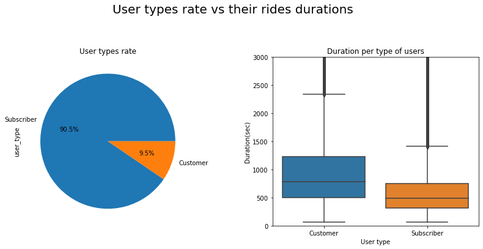

## Comparing users gender rate to their ride duration

> Although 74.6% of users are male, female and other take longer rides using Ford GoBike System.

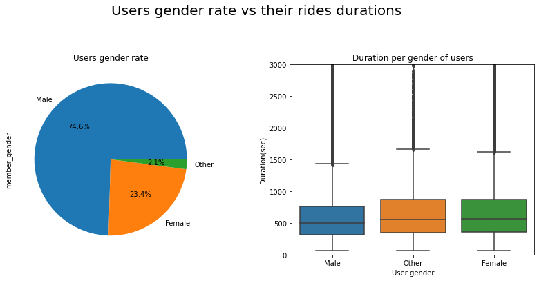

## Comparing usage rate to the duration of trips per day of the week by user type

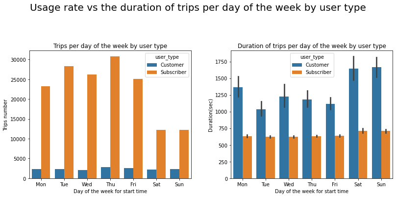